# Prueba Wilson Calle

```python
import pandas as pd
from collections import Counter
import matplotlib.pyplot as plt
```

# Cuadrados Medios

```python
x0 = 8952
digitos=4
simulaciones=100
iteraCC=[]
Ni = 1

for i in range(0,simulaciones):
    LXn=[]
    LXc=[]
    Li=[]
    LL=[]
    LUi=[]
    LRn=[]
    XNC=[]
    cont=0
    iteracion=1
    Xci=int(x0) * int(x0)
    Xcsi=str(Xci)
    while(len(Xcsi) < 8):
        Xcsi="0"+Xcsi

    Longitudi=len(Xcsi)
    Uii=Xcsi[int((Longitudi/2)-2):int((Longitudi/2)+2)]
    #print("Semilla X0= ",x0, "Semilla nueva= ", Uii)
    x0=int(Uii)+100
    Xn=x0
    while(iteracion==1):
        #print(iteracion)
        Xc=int(Xn) * int(Xn)
        Xcs=str(Xc)
        while(len(Xcs) < 8):
            Xcs="0"+Xcs

        Longitud=len(Xcs)
        Ui=Xcs[int((Longitud/2)-2):int((Longitud/2)+2)]
        Nn="1"
        while(len(Nn)<(digitos+1)):
            Nn=Nn+"0"
        Rn=int(Ui)/int(Nn)
        #print("Iteración: ",iteracion)
        Li.append(iteracion)
        #print("Xn: ",Xn)
        LXn.append(Xn)
        #print("Xn * Xn: ",Xcs)
        LXc.append(Xcs)
        #print("Longitud: ",Longitud)
        #print("Ui: ",Ui)
        LUi.append(Ui)
        #print(Nn)
        #print("Randomico: ",Rn)
        LRn.append(Rn)
        Xn=Ui
        #print(Xn)
        #print(LXn)
        if Xn in LXn:
            #print("Esta")
            #print(iteracion)
            iteraCC.append(cont)
            iteracion=0
        cont=cont+1
```

```python
print(iteraCC)
```

```
[58, 29, 59, 88, 13, 91, 28, 28, 68, 55, 62, 8, 54, 28, 77, 41, 8, 48, 35, 37, 48, 51, 27, 3, 45, 12, 82, 9, 47, 13, 23, 18, 13, 86, 38, 7, 51, 5, 8, 3, 49, 54, 84, 34, 14, 55, 5, 27, 13, 19, 27, 9, 57, 55, 10, 3, 32, 56, 69, 4, 55, 36, 67, 6, 28, 70, 86, 31, 71, 18, 36, 53, 8, 9, 26, 15, 23, 47, 30…
```

```
[58, 29, 59, 88, 13, 91, 28, 68, 55, 62, 8, 54, 77, 41, 48, 35, 37, 51, 27, 3, 45, 12, 82, 9, 47, 23, 18, 86, 38, 7, 5, 49, 84, 34, 14, 19, 57, 10, 32, 56, 69, 4, 36, 67, 6, 70, 31, 71, 53, 26, 15, 30, 11, 1]
[2, 1, 2, 1, 4, 1, 4, 1, 4, 1, 4, 2, 2, 1, 2, 1, 1, 2, 3, 3, 1, 1, 1, 3, 2, 2, 2, 2, 1, 1, 8, 1, 1, 1, 1, 1, 1, 1, 1, 1, 1, 2, 2, 1, 2, 1, 1, 1, 1, 1, 1, 2, 1, 8]
```

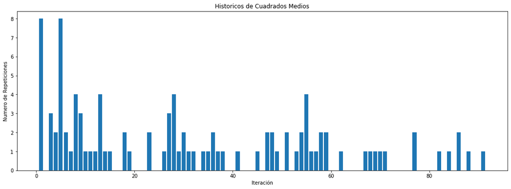

```python
X=list(Counter(iteraCC).keys())
Y=list(Counter(iteraCC).values())

print(X)
print(Y)
fig, gra = plt.subplots(figsize = (18, 6))

gra.bar(X,Y)
plt.title('Historicos de Cuadrados Medios')
plt.xlabel('Iteración')
plt.ylabel('Numero de Repeticiones')
```

# Congruencia Lineal

```python
a=3
b=5
m=19
x0=1520

conteo=[]
i=0
Xn=0.0
Un=0.0

Liter=[]
Xni=x0
for i in range(0,100):
    a=a+3
    b=b+1
    m=m+3
    itera=0
    LXn=[]
    LUn=[]
    #print("Simu: ",i)
    #print("Inicia con: ",Xni)
    Xni= (a * Xni + b) % m
    Uni=Xni/m
    #print("Nueva Semilla: ",Xni)
    Xn=Xni
    while(itera==0):
        Xn= (a * Xn + b) % m
        LXn.append(Xn)
        Un=Xn/m
        #print(Un)
        #print(LUn)
        if Un in LUn:
            #print("Esta")
            conteo.append(i)
            itera=1
        else:
            LUn.append(Un)
            i=i+1


#print(conteo)
```

```python
print(conteo)
```

```
[10, 11, 3, 13, 21, 23, 8, 21, 30, 51, 16, 21, 26, 43, 15, 81, 22, 35, 36, 97, 30, 55, 32, 29, 70, 26, 28, 129, 54, 47, 36, 53, 90, 143, 44, 49, 42, 55, 55, 177, 110, 55, 60, 73, 74, 71, 48, 209, 130, 127, 64, 81, 74, 143, 76, 72, 74, 81, 100, 257, 110, 71, 68, 273, 170, 95, 76, 141, 82, 107, 84, 11…
```

```
[10, 11, 3, 13, 21, 23, 8, 30, 51, 16, 26, 43, 15, 81, 22, 35, 36, 97, 55, 32, 29, 70, 28, 129, 54, 47, 53, 90, 143, 44, 49, 42, 177, 110, 60, 73, 74, 71, 48, 209, 130, 127, 64, 76, 72, 100, 257, 68, 273, 170, 95, 141, 82, 107, 84, 117, 174, 104, 93, 126, 99, 79, 210, 148, 353, 118, 131, 87, 181, 37…
[1, 1, 1, 1, 3, 1, 1, 2, 1, 1, 2, 1, 1, 3, 1, 1, 2, 2, 4, 1, 1, 1, 1, 1, 1, 1, 1, 1, 2, 1, 1, 1, 1, 2, 1, 1, 3, 2, 1, 1, 1, 1, 1, 3, 1, 1, 1, 1, 1, 1, 1, 1, 1, 2, 1, 1, 1, 1, 1, 1, 1, 1, 1, 1, 1, 2, 1, 1, 1, 1, 1, 1, 1, 1, 1, 1, 1, 1, 1, 1]
```

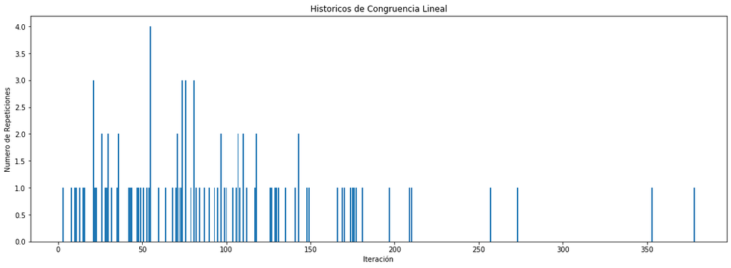

```python
XX=list(Counter(conteo).keys())
YY=list(Counter(conteo).values())

print(XX)
print(YY)
fig2, gra2 = plt.subplots(figsize = (18, 6))

gra2.bar(XX,YY)
plt.title('Historicos de Congruencia Lineal')
plt.xlabel('Iteración')
plt.ylabel('Numero de Repeticiones')
```

# conclusiones

Dentro de el motodo de Cuadrados Medios, al tomar una semilla partiendo de un valor dado, si generamos el método desde aquí vamos a notar un decrecimiento en cuanto a los numeros repetidos dada su posición y solo repeticion en un valor por muy alto, de lo contrario si hacemos lo mismo en el método de Congruencia Lineal notaremos un crecimiento pero los numeros repetidos serán iguales.

# opiniones

Los números aleatorios existirán un punto en el que estos se repetirán pero, mientras más grande sea este existirá una distancia de repetición mas prolongado con respecto a un número más pequeño. Es por ello que a opinion personal el método de congruencia lineal es el más efectivo para tener numeros aleatorios ya que existe una repetición muy baja tendiendo a 1.

# recomendaciones

Para que exista más aleatoriedad en cuanto a los números recomiendo sumar si es en el método de cuadrados medios, un valor cualquiera para que sea una semilla totalmente distinta y en el método de congruencia lineal a las variables de a, b y m se le suman numeros primos para tener asi mas notación en cuanto a la aleatoriedad nos referimos.